# Real Data and Descriptive Statistics

Thomas Manke

31 May 2016

# Famous Data Sets

R has a large range of pre-defined data sets. They are frequently used to illustrate the functionality of code and software packages. Just type “data()” to get an overview. Let’s first focus on the “iris” data set

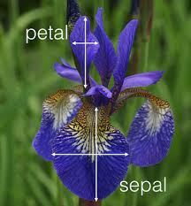

(Image from blog of mathieu.guillame-bert.com)

```r
?iris
str(iris)
```

```
## 'data.frame':    150 obs. of  5 variables:
##  $ Sepal.Length: num  5.1 4.9 4.7 4.6 5 5.4 4.6 5 4.4 4.9 ...
##  $ Sepal.Width : num  3.5 3 3.2 3.1 3.6 3.9 3.4 3.4 2.9 3.1 ...
##  $ Petal.Length: num  1.4 1.4 1.3 1.5 1.4 1.7 1.4 1.5 1.4 1.5 ...
##  $ Petal.Width : num  0.2 0.2 0.2 0.2 0.2 0.4 0.3 0.2 0.2 0.1 ...
##  $ Species     : Factor w/ 3 levels "setosa","versicolor",..: 1 1 1 1 1 1 1 1 1 1 ...
```

```r
head(iris)
```

```
##   Sepal.Length Sepal.Width Petal.Length Petal.Width Species
## 1          5.1         3.5          1.4         0.2  setosa
## 2          4.9         3.0          1.4         0.2  setosa
## 3          4.7         3.2          1.3         0.2  setosa
## 4          4.6         3.1          1.5         0.2  setosa
## 5          5.0         3.6          1.4         0.2  setosa
## 6          5.4         3.9          1.7         0.4  setosa
```

**Task**: explore this data set in terms of data structures and observables. How many rows and columns does this data frame have? Of which type and class. How do you access the data for all petal lengths?

# Descriptive Statistics

```r
summary(iris)
```

```
##   Sepal.Length    Sepal.Width     Petal.Length    Petal.Width
##  Min.   :4.300   Min.   :2.000   Min.   :1.000   Min.   :0.100
##  1st Qu.:5.100   1st Qu.:2.800   1st Qu.:1.600   1st Qu.:0.300
##  Median :5.800   Median :3.000   Median :4.350   Median :1.300
##  Mean   :5.843   Mean   :3.057   Mean   :3.758   Mean   :1.199
##  3rd Qu.:6.400   3rd Qu.:3.300   3rd Qu.:5.100   3rd Qu.:1.800
##  Max.   :7.900   Max.   :4.400   Max.   :6.900   Max.   :2.500
##        Species
##  setosa    :50
##  versicolor:50
##  virginica :50
##
##
##
```

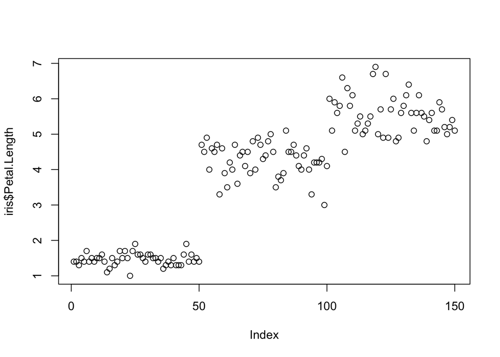

```r
plot(iris$Petal.Length) # a plot at last. Simple, but many arguments: ?plot
```

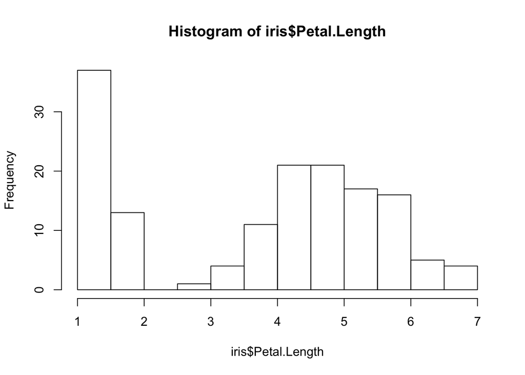

```r
hist(iris$Petal.Length) # and a histogram
```

**Task** hist() can have many arguments. Use help to find out how the histogram can be customized (e.g. number of break points, title, colors). Try some of it.

# Boxplot: a more condensed summary

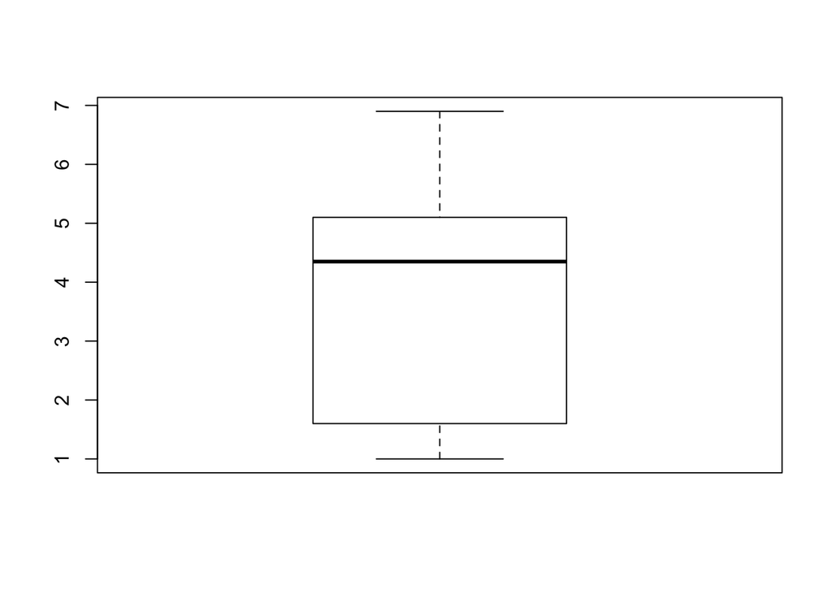

```r
boxplot(iris$Petal.Length)
```

**Task**: The boxplot above is for *all* data. Create a boxplot of petal length for species “setosa” only.

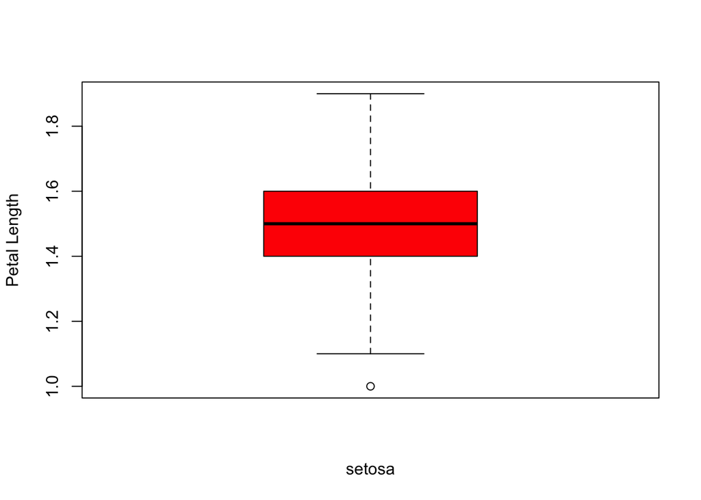

Boxplot understands data frames

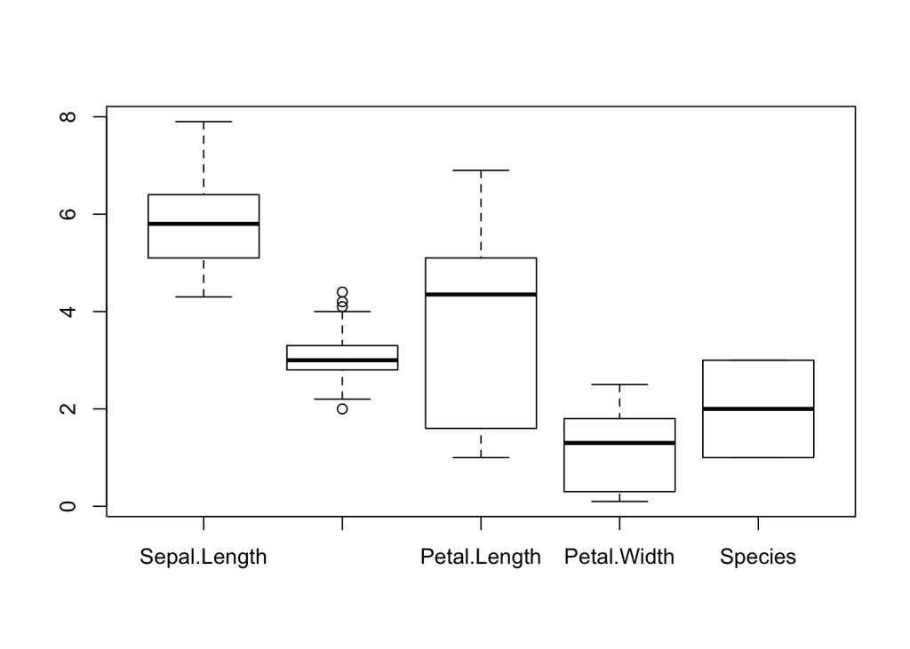

```r
boxplot(iris) # What does the boxplot for Species mean?
```

# Interlude: Factors = categorical variables

Factors denote a special class of R-objects that can be thought of as categories (here: species). They have a given number of *levels* which are internally represented as integers.

```r
class(iris$Species)
```

```
## [1] "factor"
```

```r
typeof(iris$Species)
```

```
## [1] "integer"
```

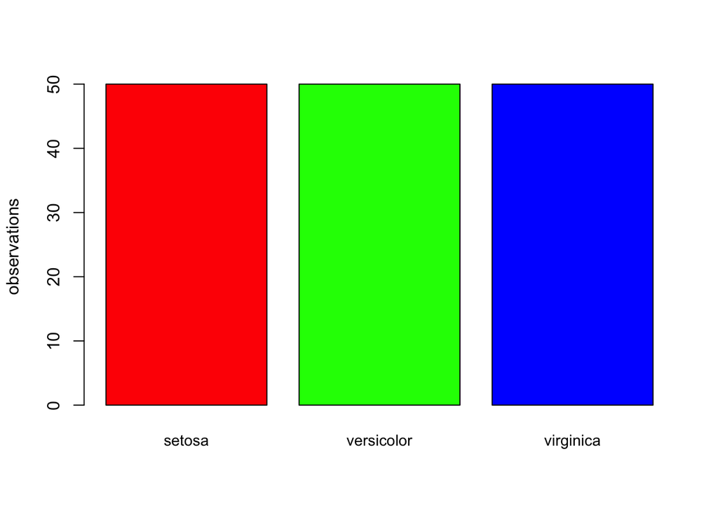

```r
ts=table(iris$Species)  # returns a contigency table ~> histogram for categorical data
barplot(ts, col=rainbow(3), ylab="observations", cex.names=0.9)
```

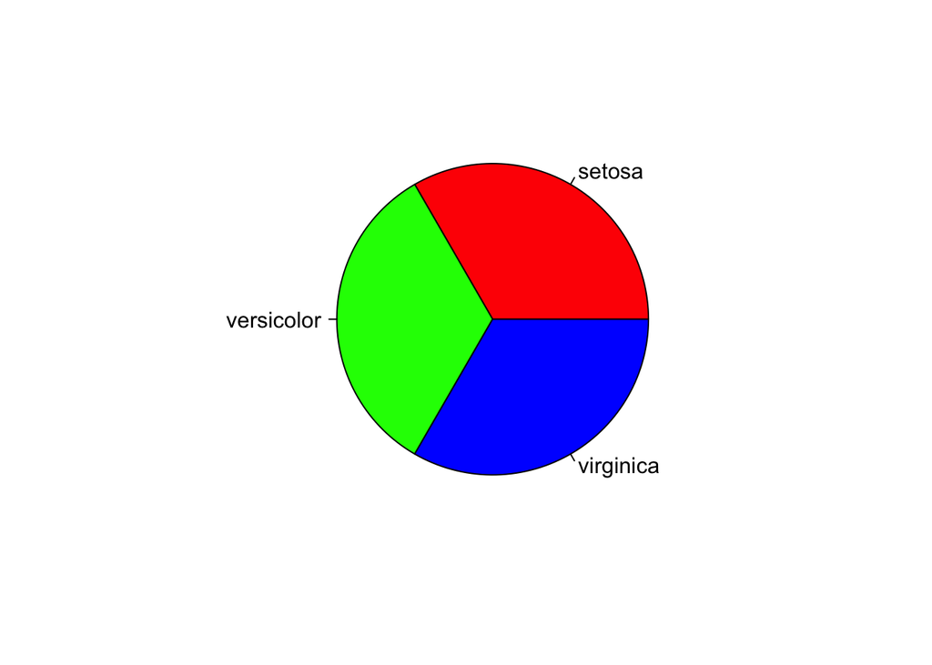

```r
pie(ts,col=rainbow(3))
```

Boxplot understands factors in data frames

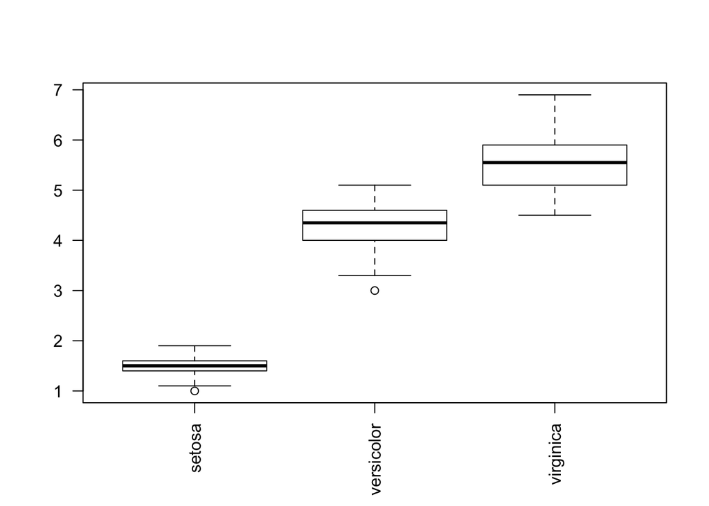

```r
boxplot( Petal.Length ~ Species, data = iris, las=2) # what does las=2 do ?
```

**Task**: Use help to add three different colors:

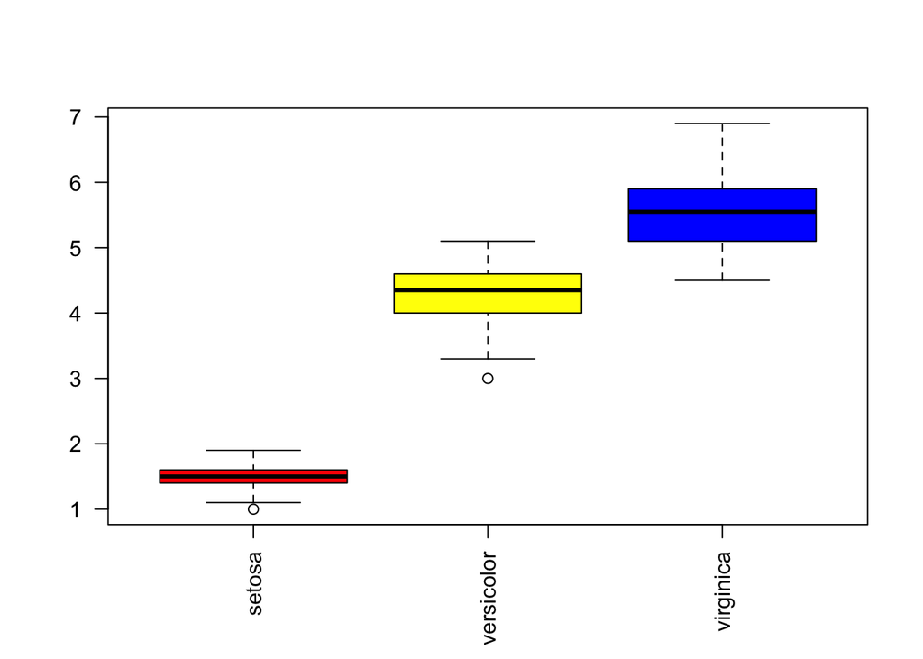

# Correlations

If a data set has many numerical variables we often want to understand their correlations structure

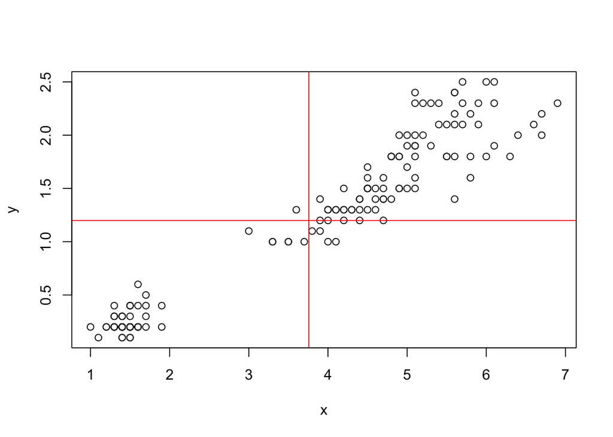

```r
x=iris$Petal.Length
y=iris$Petal.Width
plot(x,y)                              # again: this can be customized
abline(v=mean(x),h=mean(y),col="red")  # add vertical/horizontal lines
```

```r
cor(x,y)                               # a correlation coefficient: which one?
```

```
## [1] 0.9628654
```

# All-Against-All Correlations

**Task**: remove the Species variable from “iris” and store the result in a new data.frame “niris”

```
## 'data.frame':    150 obs. of  4 variables:
##  $ Sepal.Length: num  5.1 4.9 4.7 4.6 5 5.4 4.6 5 4.4 4.9 ...
##  $ Sepal.Width : num  3.5 3 3.2 3.1 3.6 3.9 3.4 3.4 2.9 3.1 ...
##  $ Petal.Length: num  1.4 1.4 1.3 1.5 1.4 1.7 1.4 1.5 1.4 1.5 ...
##  $ Petal.Width : num  0.2 0.2 0.2 0.2 0.2 0.4 0.3 0.2 0.2 0.1 ...
```

```r
cor(niris)   # correlation matrix. Which correlation coefficient?
```

```
##              Sepal.Length Sepal.Width Petal.Length Petal.Width
## Sepal.Length    1.0000000  -0.1175698    0.8717538   0.8179411
## Sepal.Width    -0.1175698   1.0000000   -0.4284401  -0.3661259
## Petal.Length    0.8717538  -0.4284401    1.0000000   0.9628654
## Petal.Width     0.8179411  -0.3661259    0.9628654   1.0000000
```

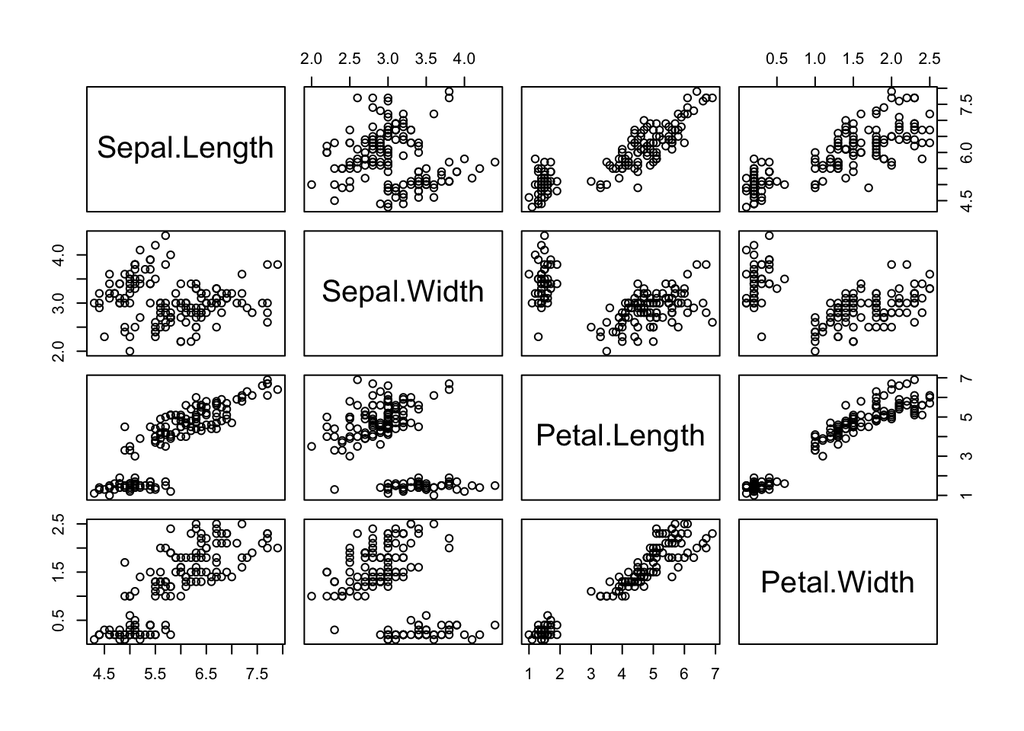

```r
pairs(niris) # provide a visualization, try also plot(iris)
```

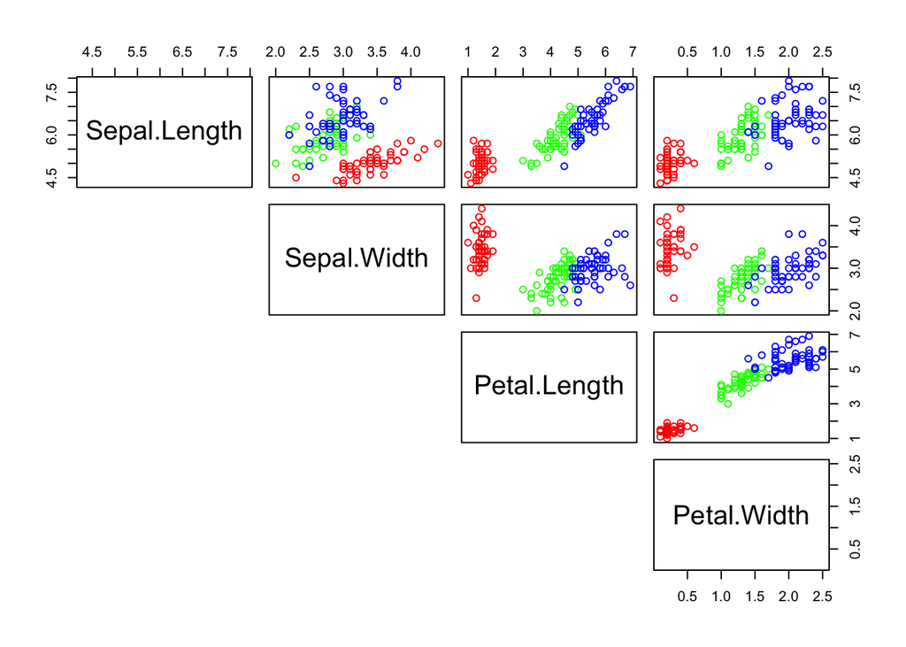

```r
# assign species-colors to each observation
cols <- rainbow(3)[iris$Species]           # understand how color is defined
pairs(niris, col=cols, lower.panel=NULL)   # "cols" was defined in task above
```

# From Correlations to Models

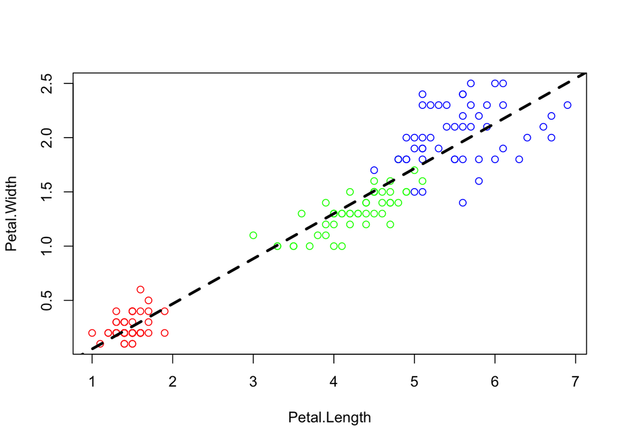

```r
plot(Petal.Width ~ Petal.Length, data=iris, col=cols) # use model ("formula") notation
fit=lm(Petal.Width ~ Petal.Length, data=iris)       # fit a linear model
abline(fit, lwd=3, lty=2)                           # add regression line
```

**Task**: What kind of class / data type is the object “fit”? Extract the coefficients of the fitted line and determine the residual degrees of freedom.

```
##  (Intercept) Petal.Length
##   -0.3630755    0.4157554
```

```
## [1] 148
```

# Reporting the fit (model)

```r
coefficients(fit)
```

```
##  (Intercept) Petal.Length
##   -0.3630755    0.4157554
```

```r
confint(fit)   # Try to change the confidence level: ?confint
```

```
##                   2.5 %     97.5 %
## (Intercept)  -0.4416501 -0.2845010
## Petal.Length  0.3968193  0.4346915
```

```r
summary(fit)
```

```
##
## Call:
## lm(formula = Petal.Width ~ Petal.Length, data = iris)
##
## Residuals:
##      Min       1Q   Median       3Q      Max
## -0.56515 -0.12358 -0.01898  0.13288  0.64272
##
## Coefficients:
##               Estimate Std. Error t value Pr(>|t|)
## (Intercept)  -0.363076   0.039762  -9.131  4.7e-16 ***
## Petal.Length  0.415755   0.009582  43.387  < 2e-16 ***
## ---
## Signif. codes:  0 '***' 0.001 '**' 0.01 '*' 0.05 '.' 0.1 ' ' 1
##
## Residual standard error: 0.2065 on 148 degrees of freedom
## Multiple R-squared:  0.9271, Adjusted R-squared:  0.9266
## F-statistic:  1882 on 1 and 148 DF,  p-value: < 2.2e-16
```

This is a good fit - as suggested by the small p-value (and by visualization).

Here is an example of a poor fit (replace “Petal” with “Sepal)

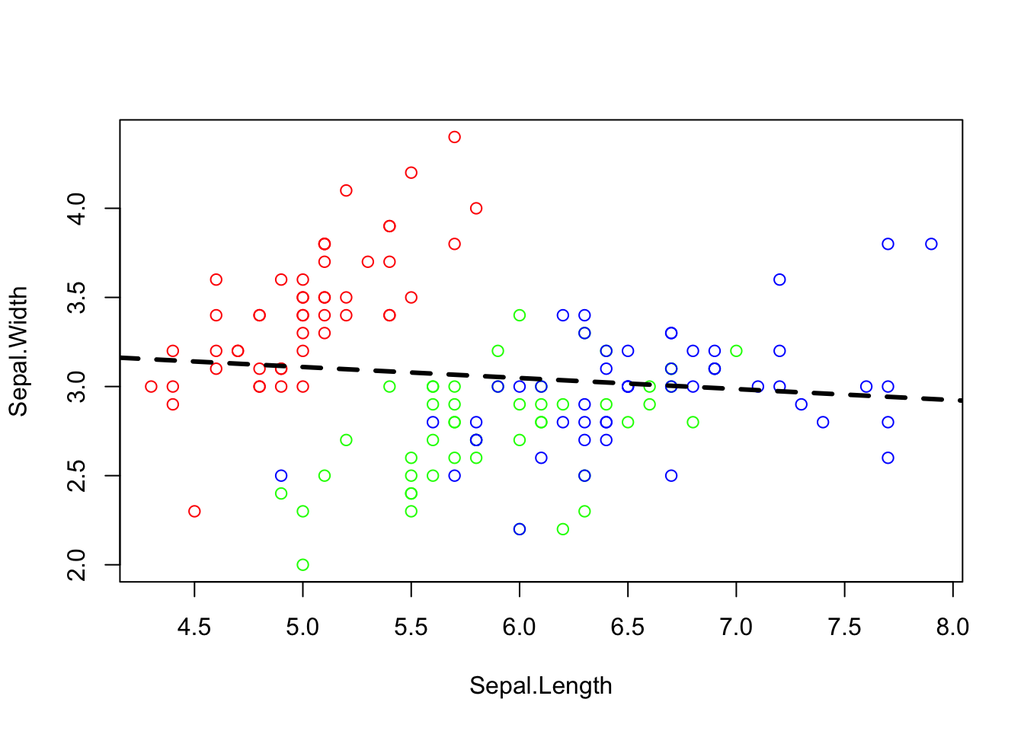

```r
plot(Sepal.Width ~ Sepal.Length, data=iris, col=cols)
fit1=lm(Sepal.Width ~ Sepal.Length, data=iris)
abline(fit1, lwd=3, lty=2)
```

```r
confint(fit1)  # the estimated slope is indistinguishable from zero
```

```
##                   2.5 %     97.5 %
## (Intercept)   2.9178767 3.92001694
## Sepal.Length -0.1467928 0.02302323
```

```r
summary(fit1)
```

```
##
## Call:
## lm(formula = Sepal.Width ~ Sepal.Length, data = iris)
##
## Residuals:
##     Min      1Q  Median      3Q     Max
## -1.1095 -0.2454 -0.0167  0.2763  1.3338
##
## Coefficients:
##              Estimate Std. Error t value Pr(>|t|)
## (Intercept)   3.41895    0.25356   13.48   <2e-16 ***
## Sepal.Length -0.06188    0.04297   -1.44    0.152
## ---
## Signif. codes:  0 '***' 0.001 '**' 0.01 '*' 0.05 '.' 0.1 ' ' 1
##
## Residual standard error: 0.4343 on 148 degrees of freedom
## Multiple R-squared:  0.01382,    Adjusted R-squared:  0.007159
## F-statistic: 2.074 on 1 and 148 DF,  p-value: 0.1519
```

**Task**: Repeat the linear regression Petal.Width ~ Petal.Length with an *outlier* in the data

```r
irisout=rbind(iris,list(5.8,3, 4, 20, "virginica"))
```

```
## 'data.frame':    151 obs. of  5 variables:
##  $ Sepal.Length: num  5.1 4.9 4.7 4.6 5 5.4 4.6 5 4.4 4.9 ...
##  $ Sepal.Width : num  3.5 3 3.2 3.1 3.6 3.9 3.4 3.4 2.9 3.1 ...
##  $ Petal.Length: num  1.4 1.4 1.3 1.5 1.4 1.7 1.4 1.5 1.4 1.5 ...
##  $ Petal.Width : num  0.2 0.2 0.2 0.2 0.2 0.4 0.3 0.2 0.2 0.1 ...
##  $ Species     : Factor w/ 3 levels "setosa","versicolor",..: 1 1 1 1 1 1 1 1 1 1 ...
```

```
##   Sepal.Length    Sepal.Width     Petal.Length   Petal.Width
##  Min.   :4.300   Min.   :2.000   Min.   :1.00   Min.   : 0.100
##  1st Qu.:5.100   1st Qu.:2.800   1st Qu.:1.60   1st Qu.: 0.300
##  Median :5.800   Median :3.000   Median :4.30   Median : 1.300
##  Mean   :5.843   Mean   :3.057   Mean   :3.76   Mean   : 1.324
##  3rd Qu.:6.400   3rd Qu.:3.300   3rd Qu.:5.10   3rd Qu.: 1.800
##  Max.   :7.900   Max.   :4.400   Max.   :6.90   Max.   :20.000
##        Species
##  setosa    :50
##  versicolor:50
##  virginica :51
##
##
##
```

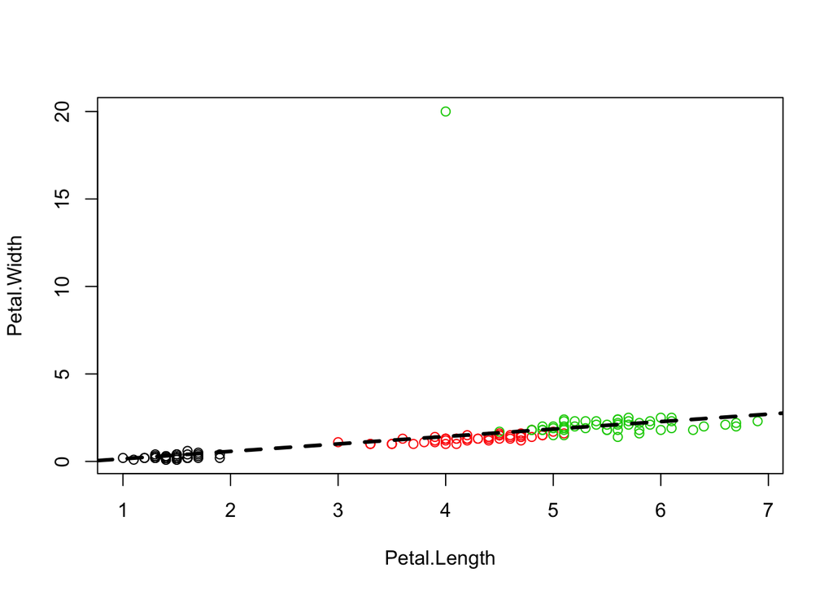

```
##
## Call:
## lm(formula = Petal.Width ~ Petal.Length, data = irisout)
##
## Residuals:
##     Min      1Q  Median      3Q     Max
## -0.7068 -0.2507 -0.1283  0.0070 18.5739
##
## Coefficients:
##              Estimate Std. Error t value Pr(>|t|)
## (Intercept)  -0.27563    0.29658  -0.929    0.354
## Petal.Length  0.42544    0.07149   5.951 1.83e-08 ***
## ---
## Signif. codes:  0 '***' 0.001 '**' 0.01 '*' 0.05 '.' 0.1 ' ' 1
##
## Residual standard error: 1.541 on 149 degrees of freedom
## Multiple R-squared:  0.192,  Adjusted R-squared:  0.1866
## F-statistic: 35.41 on 1 and 149 DF,  p-value: 1.83e-08
```

# Diagnostic Plots

“fit” is a large object of the lm-class which contains also lots of diagnostic informmation. Notice how the behaviour of “plot” changes.

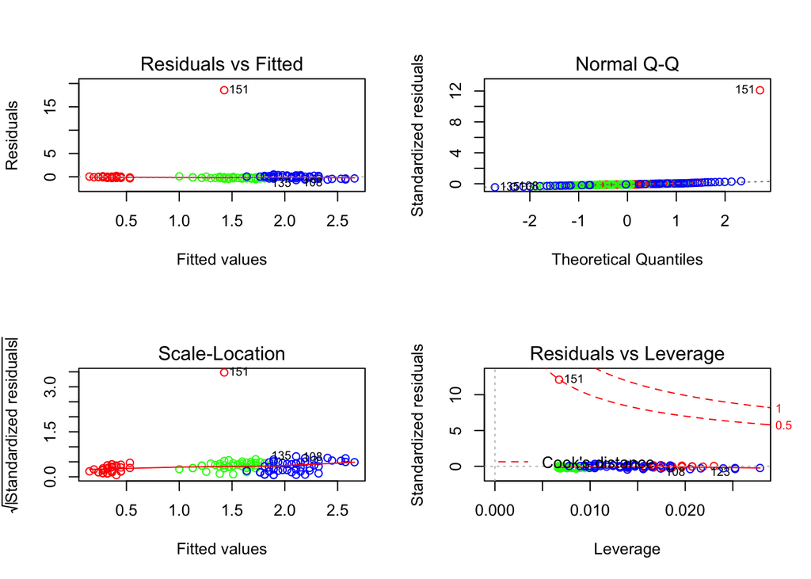

```r
op=par(no.readonly=TRUE)  # safe only resettable graphical parameters, avoids many warnings
par(mfrow=c(2,2))         # change graphical parameters: 2x2 images on device
plot(fit2,col=cols)       # four plots rather than one
```

```r
par(op)                   # reset graphical parameters
```

more examples here: http://www.statmethods.net/stats/regression.html

Linear models $y_i=\beta_0 + \beta_1 * x_i + \epsilon_i$ make certain assumptions ($\epsilon_i \propto N(0,\sigma^2)$)

- residuals $\epsilon_i$ are independent from each other (non-linear patterns?)
- residuals are normally distributed
- have equal variance $\sigma^2$ (homoscedascity)
- are there outliers (large residuals) or observations with strong influence on fit

# Comparing (nested) models

```r
fit1=lm(Petal.Width ~ Petal.Length, data=iris)            # fit a linear model
fit2=lm(Petal.Width ~ Petal.Length + Species, data=iris)  # add one variable Species
anova(fit1, fit2)
```

```
## Analysis of Variance Table
##
## Model 1: Petal.Width ~ Petal.Length
## Model 2: Petal.Width ~ Petal.Length + Species
##   Res.Df    RSS Df Sum of Sq      F    Pr(>F)
## 1    148 6.3101
## 2    146 4.7116  2    1.5984 24.766 5.482e-10 ***
## ---
## Signif. codes:  0 '***' 0.001 '**' 0.01 '*' 0.05 '.' 0.1 ' ' 1
```

# Limitations of correlation and regression analysis

**Homework**: Look at the Anscombe data set with 4 different variable pairs. Calculate Spearman and Pearson correlation coefficients for the same 4 pairs.

```r
?anscombe
str(anscombe)
head(anscombe)
example(anscombe)
?cor
```

# Logistic regression

Goal: predict species based on features

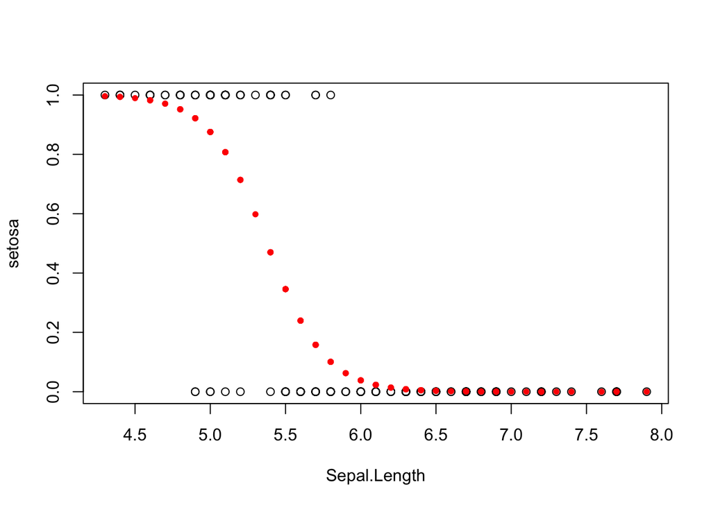

```r
x=iris
x$setosa = (x$Species=="setosa")    # create new binary variable
x$col="black"                       # default color for plot
plot(setosa ~ Sepal.Length, data=x, col=x$col)

model=glm(setosa ~ Sepal.Length, data=x, family=binomial(logit))     # generalized linear model --> logistic regression

points(fitted(model) ~ Sepal.Length, data=x, col="red", pch=20)
```

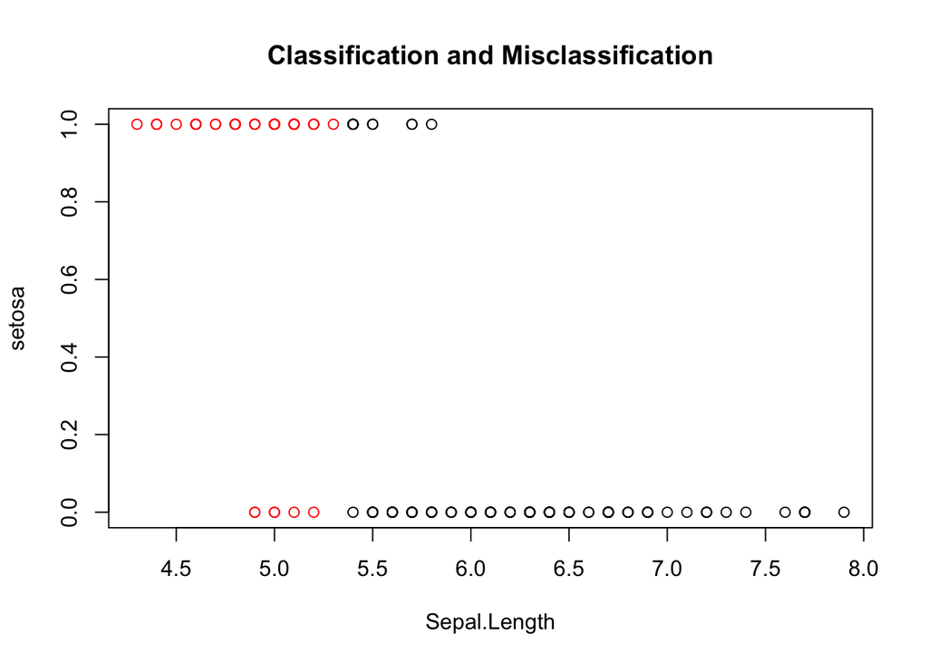

```r
x$col="black"
x$col[fitted(model)>0.5]="red"     # classify (and color red) if setosa is probable
plot(setosa ~ Sepal.Length, data=x, col=x$col, main="Classification and Misclassification")
```

```r
x$Species = NULL                                       # remove Species variable from x
model=glm(setosa ~ ., family=binomial(logit), data=x)  # model with _all_ features/variables
```

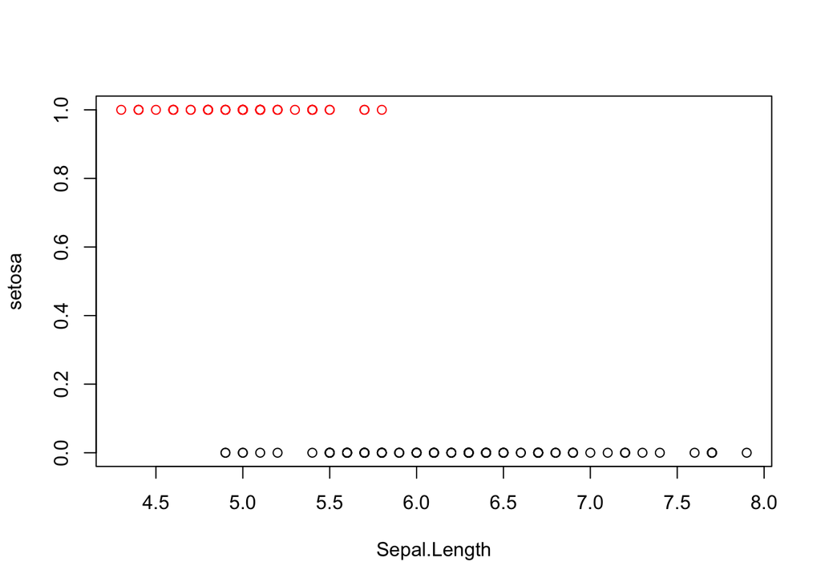

```r
x$col="black"
x$col[fitted(model)>0.5]="red"
plot(setosa ~ Sepal.Length, data=x, col=x$col)         # perfect predictor
```

# Review:

- use and understand frequently used data sets (iris)
- summary for descriptive statistics
- plot() for X-Y plots and overloading for other classes (lm)
- hist(), boxplot()
- customize arguments: line width, colours, …
- correlations: cor()
- linear model lm(): fitting, summary and interpretation
- generalized linear model glm()
- Notice that the data used was extremely clean and structured: data()